# Week 7. Foundation of Inference

### 분산분석(ANOVA)을 이용해 여러 평균을 비교하기

이번에는 `CIRI` 데이터를 이용해 국가들의 “고문”(torture) 유형에 따라서 1인당 GDP의 차이가 어떻게 나타나는지를 살펴보겠습니다. 먼저 고문의 유형을 분류해보겠습니다.

- 0은 50건 이상의 고문 사례가 있는 경우
- 1은 1건에서 49건 사이 사례를 가지는 경우
- 2는 보고된 고문 사례가 아예 없는 경우입니다.

```r
table(QOG$ciri_tort) %>% knitr::kable()
```

| Var1 | Freq |
| --- | --- |
| 0 | 86 |
| 1 | 75 |
| 2 | 31 |

고문 유형에 따른 1인당 GDP의 분포를 그래프로 나타내 보겠습니다.

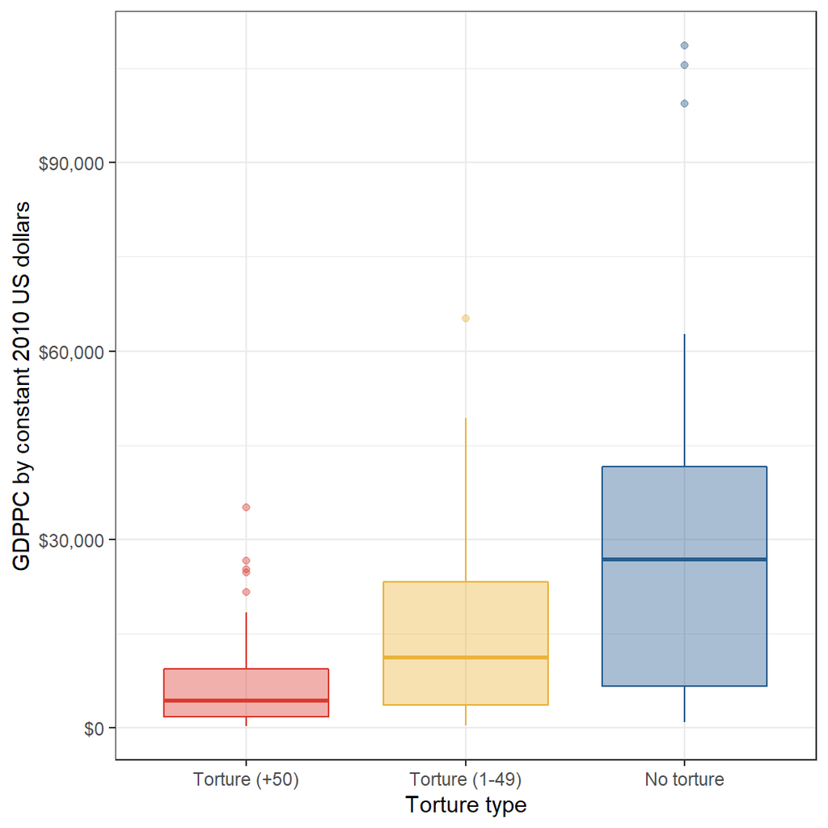

```r
QOG  %>% drop_na(ciri_tort) %>%
  ggplot(aes(y = gle_cgdpc,
             x = as.factor(ciri_tort),
             color = as.factor(ciri_tort),
             fill = as.factor(ciri_tort))) +
  geom_boxplot(show.legend = F, alpha = 0.4) +
  labs(x = "Torture type", y = "GDPPC by constant 2010 US dollars") +
  scale_color_manual(values=futurevisions("mars")) +
  scale_fill_manual(values=futurevisions("mars")) +
  scale_x_discrete(labels=c("0" = "Torture (+50)",
                            "1" = "Torture (1-49)",
                            "2" = "No torture")) +
  scale_y_continuous(labels = scales::dollar_format()) +
  theme(
    axis.title.x = element_text(margin = margin(t = 20, b = 10)),
    axis.title.y = element_text(margin = margin(r = 20, l = 10))) +
  guides(fill=FALSE) + theme_bw()
```

적어도 박스플롯은 세 집단의 평균에 유의미한 차이가 있을 수도 있다고 기대하게 합니다. 이제는 분산분석을 해봅시다. 이번에는 **R**에서 제공하는 분산분석 함수를 이용해보도록 하겠습니다.

```r
model1 <- aov(gle_cgdpc ~ as.factor(ciri_tort), data = QOG)
summary(model1)
```

```
##                       Df    Sum Sq   Mean Sq F value   Pr(>F)
## as.factor(ciri_tort)   2 1.386e+10 6.932e+09   28.03 2.18e-11 ***
## Residuals            189 4.674e+10 2.473e+08
## ---
## Signif. codes:  0 '***' 0.001 '**' 0.01 '*' 0.05 '.' 0.1 ' ' 1
## 19 observations deleted due to missingness
```

결과적으로 ANOVA의 결과는 유의수준(P-value, 여기서는 `Pr(>F)`)의 값이 매우 작게 나와 영가설($H_0: \mu_1 = \mu_2 = \mu_3, \cdots, \mu_n$)이 기각된 것을 확인할 수 있습니다. 그렇다면 만약 정치체제와 고문유형별로 집단을 더 쪼개어보면 어떻게 될까요?

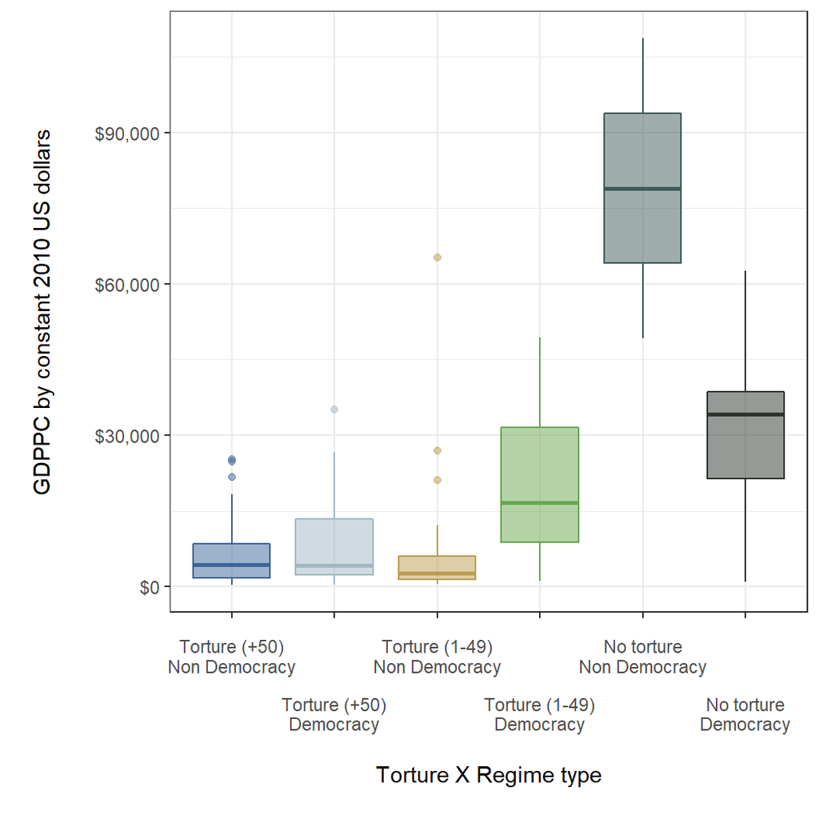

```r
## 먼저, 쪼갠 집단별로 그래프를 그려보겠습니다.
QOG %>% drop_na(ciri_tort) %>%
  drop_na(democracy) %>%
  ggplot(aes(y=gle_cgdpc,
             x=as.factor(ciri_tort):as.factor(democracy),
             color = as.factor(ciri_tort):as.factor(democracy),
             fill = as.factor(ciri_tort):as.factor(democracy),
             group=interaction(democracy, ciri_tort))) +
  geom_boxplot(show.legend = F, alpha = 0.5) +
  labs(x = "Torture X Regime type",
       y = "GDPPC by constant 2010 US dollars") +
  scale_x_discrete(labels=c("0:0" = "Torture (+50)\nNon Democracy",
                            "0:1" = "Torture (+50)\nDemocracy",
                            "1:0" = "Torture (1-49)\nNon Democracy",
                            "1:1" = "Torture (1-49)\nDemocracy",
                            "2:0" = "No torture\nNon Democracy",
                            "2:1" = "No torture\nDemocracy"),
                   guide = guide_axis(n.dodge = 2)) +
  scale_color_manual(values=futurevisions("hd")) +
  scale_fill_manual(values=futurevisions("hd")) +
  scale_y_continuous(labels = scales::dollar_format()) +
  theme(
    axis.title.x = element_text(margin = margin(t = 15, b = 10)),
    axis.title.y = element_text(margin = margin(r = 20, l = 10)),
    axis.text.x = element_text(margin = margin(t = 10))) +
  guides(fill=FALSE)
```

이렇게 두 개 유형의 조합을 분산분석하기 위해서는 마찬가지로 `aov()` 함수에 두 요인형 변수의 상호작용을 콜론(`:`)을 이용해 포함해주면 됩니다.

```r
model2 <-
  aov(gle_cgdpc ~ as.factor(ciri_tort):as.factor(democracy),
      data = QOG)
summary(model2)
```

```
##                                            Df    Sum Sq   Mean Sq F value
## as.factor(ciri_tort):as.factor(democracy)   5 1.851e+10 3.703e+09   26.09
## Residuals                                 156 2.214e+10 1.419e+08
##                                           Pr(>F)
## as.factor(ciri_tort):as.factor(democracy) <2e-16 ***
## Residuals
## ---
## Signif. codes:  0 '***' 0.001 '**' 0.01 '*' 0.05 '.' 0.1 ' ' 1
## 49 observations deleted due to missingness
```

단, 명심해야 할 것은 상호작용의 대상이 되는 변수들은 여기서 집단을 보여주는 요인형 변수여야 한다는 것입니다.

## 비율 차이: 교차표와 카이스퀘어 검정(chi-squared tests)

자료 유형에 따라서 우리가 확인해야할 통계치도 달라집니다. 예를 들어, 연속형 변수의 경우 대표값을 평균(mean)을 보면 되겠지만 이산형 변수의 경우는 비율을 볼 필요가 있습니다. 동전을 100번 던진다고 할 때, 앞면이 56번, 뒷면이 44번 나온 경우, 사실 평균인 0.56은 앞면이 나올 확률과 동일합니다. 즉, 전체 동전을 던진 횟수에 대한 성공 횟수의 비율인 것입니다.

비율 차이를 확인하고 이 차이의 통계적 유의성을 검정하는 일련의 절차를 확인하기 위하여 두 개의 연도에 걸쳐서 여러 국가들에 걸쳐 수행된 무신론에 관한 설문조사 결과를 다운로드 해보겠습니다.

```r
download.file("http://www.openintro.org/stat/data/atheism.RData",
                destfile = "atheism.RData")
load("atheism.RData")
```

이렇게 불러온 데이터를 자세히 살펴보겠습니다.

```r
glimpse(atheism)
```

```
## Rows: 88,032
## Columns: 3
## $ nationality <fct> Afghanistan, Afghanistan, Afghanistan, Afghanistan, Afg...
## $ response    <fct> non-atheist, non-atheist, non-atheist, non-atheist, non...
## $ year        <int> 2012, 2012, 2012, 2012, 2012, 2012, 2012, 2012, 2012, 2...
```

`nationality`는 응답자의 국적을 의미하며 `year`는 설문조사가 시행된 연도, 마지막으로 `response`는 응답자가 자신이 무신론자인지 아닌지 등을 응답한 내용입니다. 그럼 응답변수만을 한 번 구체적으로 살펴보겠습니다.

```r
table(atheism$response) %>% knitr::kable()
```

| Var1 | Freq |
| --- | --- |
| atheist | 5498 |
| non-atheist | 82534 |

교차표를 이용해서 우리는 행과 열에 총계와 비율을 구할 수 있습니다. 이와 같은 빈도/비율표는 변수를 기술하기 위해서 유용하게 사용됩니다.

```r
table1 <- table(atheism$response, atheism$year)

margin.table(table1, 1) %>% knitr::kable() # 행에 총계를 계산
```

| Var1 | Freq |
| --- | --- |
| atheist | 5498 |
| non-atheist | 82534 |

```r
margin.table(table1, 2) %>% knitr::kable() # 열에 총계를 계산
```

| Var1 | Freq |
| --- | --- |
| 2005 | 36105 |
| 2012 | 51927 |

```r
prop.table(table1, 1) %>% knitr::kable() # 행에 비율을 계산
```

|  | 2005 | 2012 |
| --- | --- | --- |
| atheist | 0.3677701 | 0.6322299 |
| non-atheist | 0.4129571 | 0.5870429 |

```r
prop.table(table1, 2) %>% knitr::kable() # 열에 비율을 계산
```

|  | 2005 | 2012 |
| --- | --- | --- |
| atheist | 0.0560033 | 0.0669401 |
| non-atheist | 0.9439967 | 0.9330599 |

이번에는 2005년과 2012년 간 미국에서 무신론자의 비율이 변화가 있었는지를 검증해보도록 하겠습니다. 먼저, 미국의 응답자들만을 대상으로 하는 서브셋을 만들어보겠습니다.

```r
us <- atheism %>% dplyr::filter(nationality == "United States")
```

이렇게 만든 `us`라는 서브셋을 가지고 카이스퀘어 검정을 해보고자 합니다.

```r
prop.test(table(us$year, us$response), correct = FALSE)
```

```
##
##  2-sample test for equality of proportions without continuity
##  correction
##
## data:  table(us$year, us$response)
## X-squared = 27.49, df = 1, p-value = 1.579e-07
## alternative hypothesis: two.sided
## 95 percent confidence interval:
##  -0.05474042 -0.02509990
## sample estimates:
##     prop 1     prop 2
## 0.00998004 0.04990020
```

위에서 중요한 것이 바로 변수의 순서입니다. 어떤 기준별로 특정 변수를 볼 것인가에 따라 그 기준이 될 변수가 앞으로 가고, 분석의 대상이 될 변수가 뒤로 가는 것입니다. 예를 들어, 위의 `us` 데이터에서 `year`와 `response`의 위치를 바꾸어 보겠습니다.

```r
prop.test(table(us$response, us$year), correct = FALSE)
```

```
##
##  2-sample test for equality of proportions without continuity
##  correction
##
## data:  table(us$response, us$year)
## X-squared = 27.49, df = 1, p-value = 1.579e-07
## alternative hypothesis: two.sided
## 95 percent confidence interval:
##  -0.4405031 -0.2467397
## sample estimates:
##    prop 1    prop 2
## 0.1666667 0.5102881
```

첫 번째 코드가 두 개의 연도(2005, 2012) 별로 무신론자에 대한 응답 비율을 비교한 것이었다면, 두 번째는 무신론자냐 비무신론자냐에 따라 연도들의 비율을 비교한 결과입니다. 둘 다 두 개 집단만 가지고 있는 변수라 얼핏 비슷해 보이지만 신뢰구간과 표본 추정치(`sample estimates`)를 보면 다른 것을 확인할 수 있습니다.

그리고 한 가지 더 명심해야할 것은 **R**은 여러 줄의 코드를 중첩하여 사용하는 것도 가능하다는 것입니다. 예를 들어, 위의 코드는 아래와 같이 쓸 수도 있습니다.

```r
ustab <- table(us$year, us$response) # 아예 교차표를 먼저 저장합니다.
prop.test(ustab, correct = FALSE)    # 그리고 prop.test를 저장된 교차표로 시행합니다.
```

```
##
##  2-sample test for equality of proportions without continuity
##  correction
##
## data:  ustab
## X-squared = 27.49, df = 1, p-value = 1.579e-07
## alternative hypothesis: two.sided
## 95 percent confidence interval:
##  -0.05474042 -0.02509990
## sample estimates:
##     prop 1     prop 2
## 0.00998004 0.04990020
```

```r
# R은 때로는 중첩해서 하나의 코드에 여러 기능이 가능하게끔 하기도 합니다.
prop.test(table(atheism$year[atheism$nationality ==
                               "United States"],
                atheism$response[atheism$nationality ==
                                   "United States"]),
          correct = FALSE)
```

```
##
##  2-sample test for equality of proportions without continuity
##  correction
##
## data:  table(atheism$year[atheism$nationality == "United States"], atheism$response[atheism$nationality == "United States"])
## X-squared = 27.49, df = 1, p-value = 1.579e-07
## alternative hypothesis: two.sided
## 95 percent confidence interval:
##  -0.05474042 -0.02509990
## sample estimates:
##     prop 1     prop 2
## 0.00998004 0.04990020
```

자, 이번에는 2012년 미국 총선의 시계열 설문조사에서 자료를 사용해보도록 하겠습니다. 여기 [깃허브](https://github.com/jhomola/PS5/blob/master/anes_timeseries_2012_stata12.dta)에서도 제공하고 있습니다. 다운받았다고 생각하고 진행하겠습니다.

데이터가 꽤 규모가 있습니다. 2249개의 변수를 가지고 5914개의 관측치가 있습니다. 따라서 이렇게 큰 데이터를 사용하기 전에는 코드북을 숙지하여 어떤 변수가 어떤 것을 측정하고 있는지를 미리 파악해 두셔야 합니다.

이렇게 불러온 `ANES` 자료에서 `xtabs()` 함수를 이용하여 정당 ID와 2012년에 대통령 후부 누구에게 투표했는지를 보여주는 변수 간의 교차표를 살펴보도록 하겠습니다.

```r
anes <- anes_timeseries_2012_stata12
xtabs( ~ pid_x + presvote2012_x, data = anes) %>% knitr::kable()
```

|  | -2 | 1 | 2 | 5 |
| --- | --- | --- | --- | --- |
| -2 | 13 | 7 | 4 | 0 |
| 1 | 246 | 1219 | 15 | 5 |
| 2 | 258 | 519 | 86 | 8 |
| 3 | 242 | 451 | 35 | 19 |
| 4 | 410 | 174 | 157 | 51 |
| 5 | 164 | 47 | 381 | 18 |
| 6 | 160 | 61 | 387 | 15 |
| 7 | 115 | 18 | 627 | 2 |

```r
## xtabs()는 만약 두 개 이상 변수들에 대해 살펴보고 싶을 때 유용한 함수입니다.
table(anes$pid_x, anes$presvote2012_x) %>% knitr::kable()
```

|  | -2 | 1 | 2 | 5 |
| --- | --- | --- | --- | --- |
| -2 | 13 | 7 | 4 | 0 |
| 1 | 246 | 1219 | 15 | 5 |
| 2 | 258 | 519 | 86 | 8 |
| 3 | 242 | 451 | 35 | 19 |
| 4 | 410 | 174 | 157 | 51 |
| 5 | 164 | 47 | 381 | 18 |
| 6 | 160 | 61 | 387 | 15 |
| 7 | 115 | 18 | 627 | 2 |

만약 정당 ID와 투표 선택 간 독립성을 보기 위하여 카이스퀘어 검정을 하고 싶다고 한다면, 결측치의 문제를 고려해주어야 합니다. 결측치를 제거하지 않으면 원하는 결과를 얻을 수가 없기 때문입니다. 그럼 결측치를 확인하고 이를 제거하는 작업을 진행하겠습니다.

```r
## 변수 확인하기
table(anes$pid_x) %>% knitr::kable()
```

| Var1 | Freq |
| --- | --- |
| -2 | 24 |
| 1 | 1485 |
| 2 | 871 |
| 3 | 747 |
| 4 | 792 |
| 5 | 610 |
| 6 | 623 |
| 7 | 762 |

```r
table(anes$presvote2012_x) %>% knitr::kable()
```

| Var1 | Freq |
| --- | --- |
| -2 | 1608 |
| 1 | 2496 |
| 2 | 1692 |
| 5 | 118 |

```r
# 결측치를 제거한 데이터 서브셋을 만들기

anes.nomissing <- anes %>%
  dplyr::filter(!pid_x %in% c(-2) &
                  !presvote2012_x %in% c(-9, -6, -2))

table(anes.nomissing$pid_x) %>% knitr::kable()
```

| Var1 | Freq |
| --- | --- |
| 1 | 1239 |
| 2 | 613 |
| 3 | 505 |
| 4 | 382 |
| 5 | 446 |
| 6 | 463 |
| 7 | 647 |

```r
table(anes.nomissing$presvote2012_x) %>% knitr::kable()
```

| Var1 | Freq |
| --- | --- |
| 1 | 2489 |
| 2 | 1688 |
| 5 | 118 |

이제 각각의 변수를 요인형으로 지정해주고, 필요한 경우에는 레이블도 씌워줍니다.

```r
anes.nomissing <- anes.nomissing %>% mutate(
  pid.x = factor(pid_x),
  presvote2012 = factor(presvote2012_x,
                        labels = c("Obama", "Romney", "Other"))
)

## 이제 제거한 결측치의 레이블도 없습니다.
## 아까의 경우 결측치를 제거해 내용물은 없지만 결측치임을 보여주었던 라벨은
## 남아있었습니다. 이제는 지정한 레이블만 남습니다.

table(anes.nomissing$pid_x) %>% t() %>% knitr::kable()
```

| 1 | 2 | 3 | 4 | 5 | 6 | 7 |
| --- | --- | --- | --- | --- | --- | --- |
| 1239 | 613 | 505 | 382 | 446 | 463 | 647 |

```r
table(anes.nomissing$presvote2012_x) %>% knitr::kable()
```

| Var1 | Freq |
| --- | --- |
| 1 | 2489 |
| 2 | 1688 |
| 5 | 118 |

```r
## 결측치가 없는 상태로 다시 한 번 교차표를 보겠습니다.
xtabs( ~ pid_x + presvote2012_x, data = anes.nomissing) %>% knitr::kable()
```

| 1 | 2 | 5 |
| --- | --- | --- |
| 1219 | 15 | 5 |
| 519 | 86 | 8 |
| 451 | 35 | 19 |
| 174 | 157 | 51 |
| 47 | 381 | 18 |
| 61 | 387 | 15 |
| 18 | 627 | 2 |

```r
## 카이스퀘어 검정은 xtabs() 결과에 적용할 수 있습니다.
## 단, 변수가 두 개 이상일 경우 카이스퀘어는 작동하지 않습니다.
chisq.test(xtabs( ~ pid_x + presvote2012_x, data = anes.nomissing))
```

```
##
##  Pearson's Chi-squared test
##
## data:  xtabs(~pid_x + presvote2012_x, data = anes.nomissing)
## X-squared = 3109.4, df = 12, p-value < 2.2e-16
```

```r
## 카이스퀘어 검정을 하는 또 다른 방법입니다.
model1 <- xtabs( ~ pid_x + presvote2012_x, data = anes.nomissing)
chisq.test(model1)
```

```
##
##  Pearson's Chi-squared test
##
## data:  model1
## X-squared = 3109.4, df = 12, p-value < 2.2e-16
```

여기서는 개인 수준의 자료를 이용하여 교차표를 만들었습니다. 교차표를 하나의 데이터로 만들어 사용할 수도 있습니다.

```r
premade.table <-
  as_tibble(as.data.frame(table(anes.nomissing$pid_x,
                                anes.nomissing$presvote2012_x)))

# Examine summary table
premade.table
```

| Var1 | Var2 | Freq |
| --- | --- | --- |
| 1 | 1 | 1219 |
| 2 | 1 | 519 |
| 3 | 1 | 451 |
| 4 | 1 | 174 |
| 5 | 1 | 47 |
| 6 | 1 | 61 |
| 7 | 1 | 18 |
| 1 | 2 | 15 |
| 2 | 2 | 86 |
| 3 | 2 | 35 |

[output cut: 11 more lines]

이렇게 만든 데이터 `premade`를 사용하여 변수들의 빈도를 계산할 수도 있고, 혹은 가중치 옵션을 반영해서 교차표를 만들 수도 있습니다. 이러한 `xtabs()`로 만든 교차표로 카이스퀘어 검정을 수행할 수 있습니다.

```r
xtabs(Freq ~ Var1 + Var2, data = premade.table)
```

```
##     Var2
## Var1    1    2    5
##    1 1219   15    5
##    2  519   86    8
##    3  451   35   19
##    4  174  157   51
##    5   47  381   18
##    6   61  387   15
##    7   18  627    2
```

```r
xtabs(weight_full ~ pid_x + presvote2012_x, data = anes.nomissing)
```

```
##      presvote2012_x
## pid_x        1        2        5
##     1 927.4775  11.6343   6.5122
##     2 522.5021  93.9526  12.3696
##     3 423.2494  41.1267  16.4035
##     4 171.2671 148.6813  53.8416
##     5  44.1724 434.4794  26.5022
##     6  61.7723 440.9641  12.5760
##     7  19.7325 706.1804   2.8163
```

```r
chisq.test(xtabs(weight_full ~
                   pid_x + presvote2012_x,
                 data = anes.nomissing))
```

```
##
##  Pearson's Chi-squared test
##
## data:  xtabs(weight_full ~ pid_x + presvote2012_x, data = anes.nomissing)
## X-squared = 2995.2, df = 12, p-value < 2.2e-16
```

[^1]: King, Gary, Robert Keohane, and Sidney Verba. 1994. *Designing Social Inquiry*. Princeton: Princeton University Press.
[^2]: 엄밀하게 말하면 두 집단의 평균 차이에서 0을 또 빼기 때문에 두 집단의 차이와 0이 다른지 여부를 보는 것이다.
[^3]: 표준오차는 여러 번 표본들 하나의 모집단으로 뽑았을 때, 그 각 표본의 평균들 간의 표준편차를 의미한다. 따라서 모집단에서 표본을 뽑음으로써 필연적으로 발생할 수밖에 없는 표본들의 평균의 차이들의 평균을 의미한다.